# FordGo Bike Data Exploration

##### By Pradeep Gurunathan

- Introduction
  - Packages used
- Gathering data
- Assessing data
- Cleaning data
- Store Data
- Analyze Data
- Univariate Exploration
- Bivariate Exploration
- Multivariate Exploration

## Introduction

Ford GoBike is a regional public bicycle sharing system in the San Francisco Bay Area, California. Beginning operation in August 2013 as Bay Area Bike Share, the Ford GoBike system currently has over 2,600 bicycles in 262 stations across San Francisco, East Bay and San Jose. On June 28, 2017, the system officially launched as Ford GoBike in a partnership with Ford Motor Company. After Motivate's acquisition by Lyft, the system was renamed to Bay Wheels in June 2019.

Ford GoBike, like other bike share systems, consists of a fleet of specially designed, sturdy and durable bikes that are locked into a network of docking stations throughout the city. The bikes can be unlocked from one station and returned to any other station in the system, making them ideal for one-way trips. The bikes are available for use 24 hours/day, 7 days/week, 365 days/year and riders have access to all bikes in the network when they become a member or purchase a pass.

### Packages used

```python
# import all packages and set plots to be embedded inline
import numpy as np
import pandas as pd
import matplotlib.pyplot as plt
import seaborn as sns
import datetime
import glob
import os

%matplotlib inline

import warnings
warnings.filterwarnings('ignore')
```

## Preliminary Wrangling

This document explores the Ford GoBike's trip data for public containing rides from Jan 2018 to Dec 2018.

## Gathering data

> **Firstly, I saved all the csv files from the FordGoBike website in a folder. After this, I used the glob and os modules to combine all the files into a single file fordgobike.csv**

```python
path = r'C:\Users\Pradeep Gurunathan\FordGo_project_visualization\Data'
all_files = glob.glob(os.path.join(path, "*.csv"))
df = pd.concat((pd.read_csv(f) for f in all_files), ignore_index = True)
df.to_csv('fordgobike.csv', index = False)
```

## Assessing Data

In this section data is assess that was gathered, both visually and programmatically for quality and tidiness issues.

The quality of data is assessed against dimensions or criteria concerning the content: completeness, validity, accuracy and consistency.

```python
df = pd.read_csv('fordgobike.csv')
```

```python
df.head(10)
```

|  | duration_sec | start_time | end_time | start_station_id | start_station_name | start_station_latitude | start_station_longitude | end_station_id | end_station_name | end_station_latitude | end_station_longitude | bike_id | user_type | member_birth_year | member_gender | bike_share_for_all_trip |
| --- | --- | --- | --- | --- | --- | --- | --- | --- | --- | --- | --- | --- | --- | --- | --- | --- |
| 0 | 75284 | 2018-01-31 22:52:35.2390 | 2018-02-01 19:47:19.8240 | 120.0 | Mission Dolores Park | 37.761420 | -122.426435 | 285.0 | Webster St at O'Farrell St | 37.783521 | -122.431158 | 2765 | Subscriber | 1986.0 | Male | No |
| 1 | 85422 | 2018-01-31 16:13:34.3510 | 2018-02-01 15:57:17.3100 | 15.0 | San Francisco Ferry Building (Harry Bridges Pl... | 37.795392 | -122.394203 | 15.0 | San Francisco Ferry Building (Harry Bridges Pl... | 37.795392 | -122.394203 | 2815 | Customer | NaN | NaN | No |
| 2 | 71576 | 2018-01-31 14:23:55.8890 | 2018-02-01 10:16:52.1160 | 304.0 | Jackson St at 5th St | 37.348759 | -121.894798 | 296.0 | 5th St at Virginia St | 37.325998 | -121.877120 | 3039 | Customer | 1996.0 | Male | No |
| 3 | 61076 | 2018-01-31 14:53:23.5620 | 2018-02-01 07:51:20.5000 | 75.0 | Market St at Franklin St | 37.773793 | -122.421239 | 47.0 | 4th St at Harrison St | 37.780955 | -122.399749 | 321 | Customer | NaN | NaN | No |
| 4 | 39966 | 2018-01-31 19:52:24.6670 | 2018-02-01 06:58:31.0530 | 74.0 | Laguna St at Hayes St | 37.776435 | -122.426244 | 19.0 | Post St at Kearny St | 37.788975 | -122.403452 | 617 | Subscriber | 1991.0 | Male | No |
| 5 | 6477 | 2018-01-31 22:58:44.8670 | 2018-02-01 00:46:41.9080 | 236.0 | Market St at 8th St | 37.803686 | -122.282497 | 160.0 | West Oakland BART Station | 37.805318 | -122.294837 | 1306 | Customer | NaN | NaN | No |
| 6 | 453 | 2018-01-31 23:53:53.6320 | 2018-02-01 00:01:26.8050 | 110.0 | 17th & Folsom Street Park (17th St at Folsom St) | 37.763708 | -122.415204 | 134.0 | Valencia St at 24th St | 37.752428 | -122.420628 | 3571 | Subscriber | 1988.0 | Male | No |
| 7 | 180 | 2018-01-31 23:52:09.9030 | 2018-01-31 23:55:10.8070 | 81.0 | Berry St at 4th St | 37.775880 | -122.393170 | 93.0 | 4th St at Mission Bay Blvd S | 37.770407 | -122.391198 | 1403 | Subscriber | 1980.0 | Male | No |
| 8 | 996 | 2018-01-31 23:34:56.0040 | 2018-01-31 23:51:32.6740 | 134.0 | Valencia St at 24th St | 37.752428 | -122.420628 | 4.0 | Cyril Magnin St at Ellis St | 37.785881 | -122.408915 | 3675 | Subscriber | 1987.0 | Male | Yes |
| 9 | 825 | 2018-01-31 23:34:14.0270 | 2018-01-31 23:47:59.8090 | 305.0 | Ryland Park | 37.342725 | -121.895617 | 317.0 | San Salvador St at 9th St | 37.333955 | -121.877349 | 1453 | Subscriber | 1994.0 | Female | Yes |

```python
df.tail(10)
```

|  | duration_sec | start_time | end_time | start_station_id | start_station_name | start_station_latitude | start_station_longitude | end_station_id | end_station_name | end_station_latitude | end_station_longitude | bike_id | user_type | member_birth_year | member_gender | bike_share_for_all_trip |
| --- | --- | --- | --- | --- | --- | --- | --- | --- | --- | --- | --- | --- | --- | --- | --- | --- |
| 1863711 | 760 | 2018-12-01 00:17:29.9600 | 2018-12-01 00:30:10.1780 | 73.0 | Pierce St at Haight St | 37.771793 | -122.433708 | 121.0 | Mission Playground | 37.759210 | -122.421339 | 2758 | Subscriber | 1991.0 | Male | No |
| 1863712 | 538 | 2018-12-01 00:16:34.0850 | 2018-12-01 00:25:32.4550 | 5.0 | Powell St BART Station (Market St at 5th St) | 37.783899 | -122.408445 | 39.0 | Scott St at Golden Gate Ave | 37.778999 | -122.436861 | 4384 | Subscriber | 1991.0 | Male | No |
| 1863713 | 671 | 2018-12-01 00:12:49.6400 | 2018-12-01 00:24:01.5120 | 34.0 | Father Alfred E Boeddeker Park | 37.783988 | -122.412408 | 92.0 | Mission Bay Kids Park | 37.772301 | -122.393028 | 4377 | Subscriber | 1972.0 | Male | Yes |
| 1863714 | 498 | 2018-12-01 00:14:41.7250 | 2018-12-01 00:23:00.4080 | 7.0 | Frank H Ogawa Plaza | 37.804562 | -122.271738 | 214.0 | Market St at Brockhurst St | 37.823321 | -122.275733 | 2236 | Subscriber | 1992.0 | Male | No |
| 1863715 | 1137 | 2018-12-01 00:01:49.6930 | 2018-12-01 00:20:47.5190 | 73.0 | Pierce St at Haight St | 37.771793 | -122.433708 | 50.0 | 2nd St at Townsend St | 37.780526 | -122.390288 | 273 | Subscriber | 1990.0 | Male | No |
| 1863716 | 473 | 2018-12-01 00:11:54.8110 | 2018-12-01 00:19:48.5470 | 345.0 | Hubbell St at 16th St | 37.766474 | -122.398295 | 81.0 | Berry St at 4th St | 37.775880 | -122.393170 | 3035 | Subscriber | 1982.0 | Female | No |
| 1863717 | 841 | 2018-12-01 00:02:48.7260 | 2018-12-01 00:16:49.7660 | 10.0 | Washington St at Kearny St | 37.795393 | -122.404770 | 58.0 | Market St at 10th St | 37.776619 | -122.417385 | 2034 | Subscriber | 1999.0 | Female | No |
| 1863718 | 260 | 2018-12-01 00:05:27.6150 | 2018-12-01 00:09:47.9560 | 245.0 | Downtown Berkeley BART | 37.870139 | -122.268422 | 255.0 | Virginia St at Shattuck Ave | 37.876573 | -122.269528 | 2243 | Subscriber | 1991.0 | Male | No |
| 1863719 | 292 | 2018-12-01 00:03:06.5490 | 2018-12-01 00:07:59.0800 | 93.0 | 4th St at Mission Bay Blvd S | 37.770407 | -122.391198 | 126.0 | Esprit Park | 37.761634 | -122.390648 | 545 | Subscriber | 1963.0 | Male | No |
| 1863720 | 150 | 2018-12-01 00:03:05.7420 | 2018-12-01 00:05:36.0260 | 107.0 | 17th St at Dolores St | 37.763015 | -122.426497 | 119.0 | 18th St at Noe St | 37.761047 | -122.432642 | 4319 | Subscriber | NaN | NaN | No |

```python
# Information of the dataset
df.info(verbose=True,null_counts=True)
```

```
<class 'pandas.core.frame.DataFrame'>
RangeIndex: 1863721 entries, 0 to 1863720
Data columns (total 16 columns):
 #   Column                   Non-Null Count    Dtype
---  ------                   --------------    -----
 0   duration_sec             1863721 non-null  int64
 1   start_time               1863721 non-null  object
 2   end_time                 1863721 non-null  object
 3   start_station_id         1851950 non-null  float64
 4   start_station_name       1851950 non-null  object
 5   start_station_latitude   1863721 non-null  float64
 6   start_station_longitude  1863721 non-null  float64
 7   end_station_id           1851950 non-null  float64
 8   end_station_name         1851950 non-null  object
 9   end_station_latitude     1863721 non-null  float64
 10  end_station_longitude    1863721 non-null  float64
 11  bike_id                  1863721 non-null  int64
 12  user_type                1863721 non-null  object
 13  member_birth_year        1753003 non-null  float64
 14  member_gender            1753354 non-null  object
 15  bike_share_for_all_trip  1863721 non-null  object
dtypes: float64(7), int64(2), object(7)
memory usage: 227.5+ MB
```

```python
# Description for stats figures
df.describe()
```

|  | duration_sec | start_station_id | start_station_latitude | start_station_longitude | end_station_id | end_station_latitude | end_station_longitude | bike_id | member_birth_year |
| --- | --- | --- | --- | --- | --- | --- | --- | --- | --- |
| count | 1.863721e+06 | 1.851950e+06 | 1.863721e+06 | 1.863721e+06 | 1.851950e+06 | 1.863721e+06 | 1.863721e+06 | 1.863721e+06 | 1.753003e+06 |
| mean | 8.573026e+02 | 1.196744e+02 | 3.776678e+01 | -1.223492e+02 | 1.181730e+02 | 3.776690e+01 | -1.223487e+02 | 2.296851e+03 | 1.983088e+03 |
| std | 2.370379e+03 | 1.003976e+02 | 1.057689e-01 | 1.654634e-01 | 1.004403e+02 | 1.056483e-01 | 1.650597e-01 | 1.287733e+03 | 1.044289e+01 |
| min | 6.100000e+01 | 3.000000e+00 | 3.726331e+01 | -1.224737e+02 | 3.000000e+00 | 3.726331e+01 | -1.224737e+02 | 1.100000e+01 | 1.881000e+03 |
| 25% | 3.500000e+02 | 3.300000e+01 | 3.777106e+01 | -1.224114e+02 | 3.000000e+01 | 3.777106e+01 | -1.224094e+02 | 1.225000e+03 | 1.978000e+03 |
| 50% | 5.560000e+02 | 8.900000e+01 | 3.778107e+01 | -1.223974e+02 | 8.800000e+01 | 3.778127e+01 | -1.223971e+02 | 2.338000e+03 | 1.985000e+03 |
| 75% | 8.720000e+02 | 1.860000e+02 | 3.779625e+01 | -1.222865e+02 | 1.830000e+02 | 3.779728e+01 | -1.222894e+02 | 3.333000e+03 | 1.991000e+03 |
| max | 8.636600e+04 | 3.810000e+02 | 4.551000e+01 | -7.357000e+01 | 3.810000e+02 | 4.551000e+01 | -7.357000e+01 | 6.234000e+03 | 2.000000e+03 |

```python
# Check for any NaN values in the data
df.isna().sum()
# As you can clearly see, member_birth_year & member_gender along with some of the starting and ending columns have NaN values
```

```
duration_sec                    0
start_time                      0
end_time                        0
start_station_id            11771
start_station_name          11771
start_station_latitude          0
start_station_longitude         0
end_station_id              11771
end_station_name            11771
end_station_latitude            0
end_station_longitude           0
bike_id                         0
user_type                       0
member_birth_year          110718
member_gender              110367
bike_share_for_all_trip         0
dtype: int64
```

```python
# Check for any duplicates in the data
df.duplicated().sum()
```

```
0
```

### Quality Issues

**Before assessing the data for visualization, there are some quality issues that need to be cleaned.**

- The following columns are not in object format:
  - start_station_id
  - bike_id
  - end_station_id
- Start/end times are not in the timestamp format.
- Member birth is in the float format, but should be converted to integer format.
- Member birthdates have a few inaccurate values(Dates prior to 1900).
- User type, gender and bike_share_for_all_trip can be set to category format.
- We can further enhance the dataset with more details extracted from Start time and end time like month, day, hour, weekday.
- We can also calculate age of the user from user birth year for any further analysis.

### Tidiness Issues

**Before assessing the data for visualization, there are some tidiness issues that need to be cleaned.**

- Drop unnecessary Columns that are not used in our analysis
- Dataset should be cleaned to form a Master Dataset future visualization purpose

## Cleaning data

Cleaning the Gathered Data based assessment of data.

Before cleaning we are taking a copy of the data.

```python
# create copies of the dataframes for cleaning
fordbikes_clean= df.copy()
```

### Define

**Converting several of the columns to the appropriate data type:**

- Bike ID, start station ID, and end station ID to object format.
- Starting and ending times to the timestamp format.
- User type, gender, and bike share for all to category format.

### Code

```python
# Changing the format to datetime format
fordbikes_clean.start_time = pd.to_datetime(fordbikes_clean.start_time)
fordbikes_clean.end_time = pd.to_datetime(fordbikes_clean.end_time)
```

```python
# Changing the user_type, member_gender, and bike_share_for_all_trip to category format
fordbikes_clean.user_type=fordbikes_clean.user_type.astype('category')
fordbikes_clean.member_gender = fordbikes_clean.member_gender.astype('category')
fordbikes_clean.bike_share_for_all_trip = fordbikes_clean.bike_share_for_all_trip.astype('category')
```

```python
# Changing the bike_id, start_station_id, and end_station_id to object format
fordbikes_clean.bike_id = fordbikes_clean.bike_id.astype(str)
fordbikes_clean.start_station_id = fordbikes_clean.start_station_id.astype(str)
fordbikes_clean.end_station_id = fordbikes_clean.end_station_id.astype(str)
```

### Test

```python
fordbikes_clean.info(verbose=True, null_counts=True)
```

```
<class 'pandas.core.frame.DataFrame'>
RangeIndex: 1863721 entries, 0 to 1863720
Data columns (total 16 columns):
 #   Column                   Non-Null Count    Dtype
---  ------                   --------------    -----
 0   duration_sec             1863721 non-null  int64
 1   start_time               1863721 non-null  datetime64[ns]
 2   end_time                 1863721 non-null  datetime64[ns]
 3   start_station_id         1863721 non-null  object
 4   start_station_name       1851950 non-null  object
 5   start_station_latitude   1863721 non-null  float64
 6   start_station_longitude  1863721 non-null  float64
 7   end_station_id           1863721 non-null  object
 8   end_station_name         1851950 non-null  object
 9   end_station_latitude     1863721 non-null  float64
 10  end_station_longitude    1863721 non-null  float64
 11  bike_id                  1863721 non-null  object
 12  user_type                1863721 non-null  category
 13  member_birth_year        1753003 non-null  float64
 14  member_gender            1753354 non-null  category
 15  bike_share_for_all_trip  1863721 non-null  category
dtypes: category(3), datetime64[ns](2), float64(5), int64(1), object(5)
memory usage: 190.2+ MB
```

### Define

> Calculate the age of each member by subtracting their birth year from the current year (2020)

### Code

```python
# Subtracting the member_birth_year from the current year(2020) to get the current ages of all the members
fordbikes_clean['member_age'] = 2020 - fordbikes_clean['member_birth_year']
```

### Test

```python
fordbikes_clean.head()
```

|  | duration_sec | start_time | end_time | start_station_id | start_station_name | start_station_latitude | start_station_longitude | end_station_id | end_station_name | end_station_latitude | end_station_longitude | bike_id | user_type | member_birth_year | member_gender | bike_share_for_all_trip | member_age |
| --- | --- | --- | --- | --- | --- | --- | --- | --- | --- | --- | --- | --- | --- | --- | --- | --- | --- |
| 0 | 75284 | 2018-01-31 22:52:35.239 | 2018-02-01 19:47:19.824 | 120.0 | Mission Dolores Park | 37.761420 | -122.426435 | 285.0 | Webster St at O'Farrell St | 37.783521 | -122.431158 | 2765 | Subscriber | 1986.0 | Male | No | 34.0 |
| 1 | 85422 | 2018-01-31 16:13:34.351 | 2018-02-01 15:57:17.310 | 15.0 | San Francisco Ferry Building (Harry Bridges Pl... | 37.795392 | -122.394203 | 15.0 | San Francisco Ferry Building (Harry Bridges Pl... | 37.795392 | -122.394203 | 2815 | Customer | NaN | NaN | No | NaN |
| 2 | 71576 | 2018-01-31 14:23:55.889 | 2018-02-01 10:16:52.116 | 304.0 | Jackson St at 5th St | 37.348759 | -121.894798 | 296.0 | 5th St at Virginia St | 37.325998 | -121.877120 | 3039 | Customer | 1996.0 | Male | No | 24.0 |
| 3 | 61076 | 2018-01-31 14:53:23.562 | 2018-02-01 07:51:20.500 | 75.0 | Market St at Franklin St | 37.773793 | -122.421239 | 47.0 | 4th St at Harrison St | 37.780955 | -122.399749 | 321 | Customer | NaN | NaN | No | NaN |
| 4 | 39966 | 2018-01-31 19:52:24.667 | 2018-02-01 06:58:31.053 | 74.0 | Laguna St at Hayes St | 37.776435 | -122.426244 | 19.0 | Post St at Kearny St | 37.788975 | -122.403452 | 617 | Subscriber | 1991.0 | Male | No | 29.0 |

```python
fordbikes_clean.info(verbose=True,null_counts=True)
```

```
<class 'pandas.core.frame.DataFrame'>
RangeIndex: 1863721 entries, 0 to 1863720
Data columns (total 17 columns):
 #   Column                   Non-Null Count    Dtype
---  ------                   --------------    -----
 0   duration_sec             1863721 non-null  int64
 1   start_time               1863721 non-null  datetime64[ns]
 2   end_time                 1863721 non-null  datetime64[ns]
 3   start_station_id         1863721 non-null  object
 4   start_station_name       1851950 non-null  object
 5   start_station_latitude   1863721 non-null  float64
 6   start_station_longitude  1863721 non-null  float64
 7   end_station_id           1863721 non-null  object
 8   end_station_name         1851950 non-null  object
 9   end_station_latitude     1863721 non-null  float64
 10  end_station_longitude    1863721 non-null  float64
 11  bike_id                  1863721 non-null  object
 12  user_type                1863721 non-null  category
 13  member_birth_year        1753003 non-null  float64
 14  member_gender            1753354 non-null  category
 15  bike_share_for_all_trip  1863721 non-null  category
 16  member_age               1753003 non-null  float64
dtypes: category(3), datetime64[ns](2), float64(6), int64(1), object(5)
memory usage: 204.4+ MB
```

### Code

```python
# Mean age of the members if around 37
fordbikes_clean.member_age.mean()
```

```
36.91203780027758
```

```python
fordbikes_clean.member_age.describe()
```

```
count    1.753003e+06
mean     3.691204e+01
std      1.044289e+01
min      2.000000e+01
25%      2.900000e+01
50%      3.500000e+01
75%      4.200000e+01
max      1.390000e+02
Name: member_age, dtype: float64
```

**As you can see, 75% of the members are under the age of 42**

```python
fordbikes_clean.member_age.describe(percentiles=[.99])
```

```
count    1.753003e+06
mean     3.691204e+01
std      1.044289e+01
min      2.000000e+01
50%      3.500000e+01
99%      6.700000e+01
max      1.390000e+02
Name: member_age, dtype: float64
```

**It's clear that around 99% of the members are below the age of 67**

```python
# Only keep the records where age under 67.It automatically removes null values.
fordbikes_clean = fordbikes_clean.query('member_age <= 67')
```

```python
# Convert the member_age and member_birth_year to integer format
fordbikes_clean.member_age = fordbikes_clean.member_age.astype(int)
fordbikes_clean.member_birth_year = fordbikes_clean.member_birth_year.astype(int)
```

### Test

```python
fordbikes_clean.sample(10)
```

|  | duration_sec | start_time | end_time | start_station_id | start_station_name | start_station_latitude | start_station_longitude | end_station_id | end_station_name | end_station_latitude | end_station_longitude | bike_id | user_type | member_birth_year | member_gender | bike_share_for_all_trip | member_age |
| --- | --- | --- | --- | --- | --- | --- | --- | --- | --- | --- | --- | --- | --- | --- | --- | --- | --- |
| 117333 | 719 | 2018-02-22 09:40:01.992 | 2018-02-22 09:52:01.407 | 16.0 | Steuart St at Market St | 37.794130 | -122.394430 | 81.0 | Berry St at 4th St | 37.775880 | -122.393170 | 3343 | Subscriber | 1978 | Female | No | 42 |
| 712231 | 734 | 2018-06-18 08:33:04.953 | 2018-06-18 08:45:19.452 | 92.0 | Mission Bay Kids Park | 37.772301 | -122.393028 | 349.0 | Howard St at Mary St | 37.781010 | -122.405666 | 3799 | Subscriber | 1988 | Male | No | 32 |
| 380280 | 625 | 2018-04-17 08:43:25.697 | 2018-04-17 08:53:51.686 | 50.0 | 2nd St at Townsend St | 37.780526 | -122.390288 | 14.0 | Clay St at Battery St | 37.795001 | -122.399970 | 2459 | Subscriber | 1994 | Male | No | 26 |
| 1686643 | 989 | 2018-11-08 08:18:47.376 | 2018-11-08 08:35:16.911 | 95.0 | Sanchez St at 15th St | 37.766219 | -122.431060 | 3.0 | Powell St BART Station (Market St at 4th St) | 37.786375 | -122.404904 | 3707 | Subscriber | 1987 | Male | No | 33 |
| 263796 | 431 | 2018-03-15 10:38:16.876 | 2018-03-15 10:45:28.685 | 296.0 | 5th St at Virginia St | 37.325998 | -121.877120 | 280.0 | San Fernando at 7th St | 37.337246 | -121.883074 | 764 | Subscriber | 1983 | Female | Yes | 37 |
| 1453815 | 741 | 2018-10-23 08:49:10.243 | 2018-10-23 09:01:31.493 | 8.0 | The Embarcadero at Vallejo St | 37.799953 | -122.398525 | 81.0 | Berry St at 4th St | 37.775880 | -122.393170 | 4419 | Subscriber | 1988 | Male | No | 32 |
| 169013 | 636 | 2018-02-08 16:55:52.053 | 2018-02-08 17:06:28.760 | 23.0 | The Embarcadero at Steuart St | 37.791464 | -122.391034 | 30.0 | San Francisco Caltrain (Townsend St at 4th St) | 37.776598 | -122.395282 | 3133 | Subscriber | 1974 | Male | No | 46 |
| 1556985 | 650 | 2018-10-06 19:50:03.110 | 2018-10-06 20:00:53.540 | 5.0 | Powell St BART Station (Market St at 5th St) | 37.783899 | -122.408445 | 74.0 | Laguna St at Hayes St | 37.776435 | -122.426244 | 2516 | Subscriber | 1991 | Male | No | 29 |
| 1253161 | 406 | 2018-09-24 16:02:48.725 | 2018-09-24 16:09:35.432 | 50.0 | 2nd St at Townsend St | 37.780526 | -122.390288 | 22.0 | Howard St at Beale St | 37.789756 | -122.394643 | 1666 | Subscriber | 1964 | Male | No | 56 |
| 602601 | 73 | 2018-05-04 08:21:54.019 | 2018-05-04 08:23:07.438 | 25.0 | Howard St at 2nd St | 37.787522 | -122.397405 | 25.0 | Howard St at 2nd St | 37.787522 | -122.397405 | 2856 | Subscriber | 1995 | Male | No | 25 |

```python
fordbikes_clean.info(null_counts=True)
```

```
<class 'pandas.core.frame.DataFrame'>
Int64Index: 1736572 entries, 0 to 1863719
Data columns (total 17 columns):
 #   Column                   Non-Null Count    Dtype
---  ------                   --------------    -----
 0   duration_sec             1736572 non-null  int64
 1   start_time               1736572 non-null  datetime64[ns]
 2   end_time                 1736572 non-null  datetime64[ns]
 3   start_station_id         1736572 non-null  object
 4   start_station_name       1725138 non-null  object
 5   start_station_latitude   1736572 non-null  float64
 6   start_station_longitude  1736572 non-null  float64
 7   end_station_id           1736572 non-null  object
 8   end_station_name         1725138 non-null  object
 9   end_station_latitude     1736572 non-null  float64
 10  end_station_longitude    1736572 non-null  float64
 11  bike_id                  1736572 non-null  object
 12  user_type                1736572 non-null  category
 13  member_birth_year        1736572 non-null  int32
 14  member_gender            1736572 non-null  category
 15  bike_share_for_all_trip  1736572 non-null  category
 16  member_age               1736572 non-null  int32
dtypes: category(3), datetime64[ns](2), float64(4), int32(2), int64(1), object(5)
memory usage: 190.5+ MB
```

```python
fordbikes_clean.member_age.describe()
```

```
count    1.736572e+06
mean     3.654417e+01
std      9.700772e+00
min      2.000000e+01
25%      2.900000e+01
50%      3.400000e+01
75%      4.200000e+01
max      6.700000e+01
Name: member_age, dtype: float64
```

### Define

> **Enhancing the dataset further by adding columns for the start month, day of the week, and hour, along with figuring out the trip duration in minutes.**

### Code

```python
# Extracting start time month (January - February)
fordbikes_clean['start_time_month'] = fordbikes_clean['start_time'].dt.strftime('%B')
```

```python
# Extracting start time month (1-12)
fordbikes_clean['start_time_month_num'] = fordbikes_clean['start_time'].dt.month.astype(int)
```

```python
# Extracting start time weekday
fordbikes_clean['start_time_weekday'] = fordbikes_clean['start_time'].dt.strftime('%a')
```

```python
# Extracting start time and end time hour
fordbikes_clean['start_time_hour'] = fordbikes_clean['start_time'].dt.hour
fordbikes_clean['end_time_hour'] = fordbikes_clean['end_time'].dt.hour
```

```python
# Extracting duration in minutes
fordbikes_clean['duration_min'] = fordbikes_clean['duration_sec']/60
fordbikes_clean['duration_min'] = fordbikes_clean['duration_min'].astype(int)
```

### Test

```python
fordbikes_clean.head()
```

|  | duration_sec | start_time | end_time | start_station_id | start_station_name | start_station_latitude | start_station_longitude | end_station_id | end_station_name | end_station_latitude | ... | member_birth_year | member_gender | bike_share_for_all_trip | member_age | start_time_month | start_time_month_num | start_time_weekday | start_time_hour | end_time_hour | duration_min |
| --- | --- | --- | --- | --- | --- | --- | --- | --- | --- | --- | --- | --- | --- | --- | --- | --- | --- | --- | --- | --- | --- |
| 0 | 75284 | 2018-01-31 22:52:35.239 | 2018-02-01 19:47:19.824 | 120.0 | Mission Dolores Park | 37.761420 | -122.426435 | 285.0 | Webster St at O'Farrell St | 37.783521 | ... | 1986 | Male | No | 34 | January | 1 | Wed | 22 | 19 | 1254 |
| 2 | 71576 | 2018-01-31 14:23:55.889 | 2018-02-01 10:16:52.116 | 304.0 | Jackson St at 5th St | 37.348759 | -121.894798 | 296.0 | 5th St at Virginia St | 37.325998 | ... | 1996 | Male | No | 24 | January | 1 | Wed | 14 | 10 | 1192 |
| 4 | 39966 | 2018-01-31 19:52:24.667 | 2018-02-01 06:58:31.053 | 74.0 | Laguna St at Hayes St | 37.776435 | -122.426244 | 19.0 | Post St at Kearny St | 37.788975 | ... | 1991 | Male | No | 29 | January | 1 | Wed | 19 | 6 | 666 |
| 6 | 453 | 2018-01-31 23:53:53.632 | 2018-02-01 00:01:26.805 | 110.0 | 17th & Folsom Street Park (17th St at Folsom St) | 37.763708 | -122.415204 | 134.0 | Valencia St at 24th St | 37.752428 | ... | 1988 | Male | No | 32 | January | 1 | Wed | 23 | 0 | 7 |
| 7 | 180 | 2018-01-31 23:52:09.903 | 2018-01-31 23:55:10.807 | 81.0 | Berry St at 4th St | 37.775880 | -122.393170 | 93.0 | 4th St at Mission Bay Blvd S | 37.770407 | ... | 1980 | Male | No | 40 | January | 1 | Wed | 23 | 23 | 3 |

5 rows × 23 columns

```python
fordbikes_clean.info(null_counts=True)
```

```
<class 'pandas.core.frame.DataFrame'>
Int64Index: 1736572 entries, 0 to 1863719
Data columns (total 23 columns):
 #   Column                   Non-Null Count    Dtype
---  ------                   --------------    -----
 0   duration_sec             1736572 non-null  int64
 1   start_time               1736572 non-null  datetime64[ns]
 2   end_time                 1736572 non-null  datetime64[ns]
 3   start_station_id         1736572 non-null  object
 4   start_station_name       1725138 non-null  object
 5   start_station_latitude   1736572 non-null  float64
 6   start_station_longitude  1736572 non-null  float64
 7   end_station_id           1736572 non-null  object
 8   end_station_name         1725138 non-null  object
 9   end_station_latitude     1736572 non-null  float64
 10  end_station_longitude    1736572 non-null  float64
 11  bike_id                  1736572 non-null  object
 12  user_type                1736572 non-null  category
 13  member_birth_year        1736572 non-null  int32
 14  member_gender            1736572 non-null  category
 15  bike_share_for_all_trip  1736572 non-null  category
 16  member_age               1736572 non-null  int32
 17  start_time_month         1736572 non-null  object
 18  start_time_month_num     1736572 non-null  int32
 19  start_time_weekday       1736572 non-null  object
 20  start_time_hour          1736572 non-null  int64
 21  end_time_hour            1736572 non-null  int64
 22  duration_min             1736572 non-null  int32
dtypes: category(3), datetime64[ns](2), float64(4), int32(4), int64(3), object(7)
memory usage: 256.7+ MB
```

### Define

#### Tidiness Issue

- Drop unnecessary Columns that are not used in our analysis
- Dataset should be cleaned to form a Master Dataset future visualization purpose

### Code

```python
fordbikes_clean.info(null_counts=True)
```

```
<class 'pandas.core.frame.DataFrame'>
Int64Index: 1736572 entries, 0 to 1863719
Data columns (total 23 columns):
 #   Column                   Non-Null Count    Dtype
---  ------                   --------------    -----
 0   duration_sec             1736572 non-null  int64
 1   start_time               1736572 non-null  datetime64[ns]
 2   end_time                 1736572 non-null  datetime64[ns]
 3   start_station_id         1736572 non-null  object
 4   start_station_name       1725138 non-null  object
 5   start_station_latitude   1736572 non-null  float64
 6   start_station_longitude  1736572 non-null  float64
 7   end_station_id           1736572 non-null  object
 8   end_station_name         1725138 non-null  object
 9   end_station_latitude     1736572 non-null  float64
 10  end_station_longitude    1736572 non-null  float64
 11  bike_id                  1736572 non-null  object
 12  user_type                1736572 non-null  category
 13  member_birth_year        1736572 non-null  int32
 14  member_gender            1736572 non-null  category
 15  bike_share_for_all_trip  1736572 non-null  category
 16  member_age               1736572 non-null  int32
 17  start_time_month         1736572 non-null  object
 18  start_time_month_num     1736572 non-null  int32
 19  start_time_weekday       1736572 non-null  object
 20  start_time_hour          1736572 non-null  int64
 21  end_time_hour            1736572 non-null  int64
 22  duration_min             1736572 non-null  int32
dtypes: category(3), datetime64[ns](2), float64(4), int32(4), int64(3), object(7)
memory usage: 256.7+ MB
```

> **Drop 'start_station_id','start_station_latitude','start_station_longitude','end_station_id','end_station_latitude','end_station_longitude'**

```python
fordbikes_clean.drop(['start_station_id','start_station_latitude','start_station_longitude','end_station_id','end_station_latitude','end_station_longitude'], axis=1,inplace=True)
```

### Test

```python
fordbikes_clean.info(null_counts=True)
```

```
<class 'pandas.core.frame.DataFrame'>
Int64Index: 1736572 entries, 0 to 1863719
Data columns (total 17 columns):
 #   Column                   Non-Null Count    Dtype
---  ------                   --------------    -----
 0   duration_sec             1736572 non-null  int64
 1   start_time               1736572 non-null  datetime64[ns]
 2   end_time                 1736572 non-null  datetime64[ns]
 3   start_station_name       1725138 non-null  object
 4   end_station_name         1725138 non-null  object
 5   bike_id                  1736572 non-null  object
 6   user_type                1736572 non-null  category
 7   member_birth_year        1736572 non-null  int32
 8   member_gender            1736572 non-null  category
 9   bike_share_for_all_trip  1736572 non-null  category
 10  member_age               1736572 non-null  int32
 11  start_time_month         1736572 non-null  object
 12  start_time_month_num     1736572 non-null  int32
 13  start_time_weekday       1736572 non-null  object
 14  start_time_hour          1736572 non-null  int64
 15  end_time_hour            1736572 non-null  int64
 16  duration_min             1736572 non-null  int32
dtypes: category(3), datetime64[ns](2), int32(4), int64(3), object(5)
memory usage: 257.2+ MB
```

### **Saving the cleaned master dataset to a new file**

```python
fordbikes_clean.to_csv('fordgobike_master.csv', index=False)
```

### What is the structure of your dataset?

The data is straightforward to understand. This data has been collected efficiently, providing a valuable collection of data to work with and draw conclusions from.

The following dataset contained features about:

- Trip Duration (seconds)
  - Start Time and Date
  - End Time and Date
- Start Station Name
- End Station Name
- Bike ID
- User Type
  - Member Year of Birth
  - Member Gender

After some cleaning, I enhanced the dataset with some features that I found necessary to perform interesting analysis.

- Member age
- Start Time Month
- Start Time Month Number
- Start Time Day of the Week
- Start Time Hour
- End Time Hour
- Duration(in min)

### What is/are the main feature(s) of interest in your dataset?

The main feature of interest in this dataset according to me is the start and end times of the ride taken i.e. month/weekday/hour. With this data, we can forecast the demand of the bikes. Moreover, we have data related to the users such as age, gender, whether the user is a paying member/casual user. This user data can be used to decide which age group or gender group to target in marketing campaigns in order to drive business decisions.

### What features in the dataset do you think will help support your investigation into your feature(s) of interest?

I think that start and end times related information will be exploited heavily for forecasting bike demand in my analysis. Along with the time based information, I will also use the customer related data such as age & gender to better understand the user-driven role behind each ride.

## Univariate Exploration

> In this section, investigate distributions of individual variables.

**Read the Cleaned Master dataset**

```python
fordgobikes_master=pd.read_csv('fordgobike_master.csv')
```

### 1. let's look at the FordGoBike usage by month.

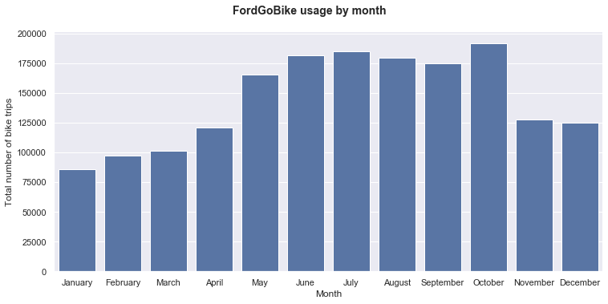

```python
# Setting the color palette to a standard one
base_color = sns.color_palette()[0]
g = sns.catplot(data=fordgobikes_master,x='start_time_month',kind='count',color=base_color,height=5, aspect=10.5/5)
g.set_axis_labels('Month','Total number of bike trips')
g.fig.suptitle('FordGoBike usage by month',y=1.05,fontsize=14,fontweight='bold')
g.set_xticklabels(rotation=0);
```

**Observation: The summer months and early-mid autumn are the most popular times to use the Ford GoBikes. October is the most popular month, with July as the second most popular, and June/August coming in closely as the third most popular months to use the bike system. The weather in San Francisco is best in the mid-late summer and usually stays sunny until returning to its usual foggy weather in the early winter months.**

### 2. let's look at the FordGoBike usage by weekday.

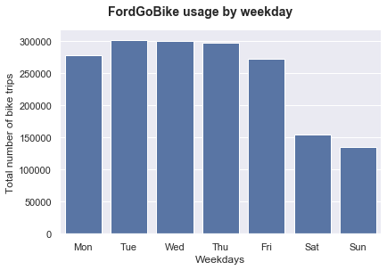

```python
weekday = ['Mon', 'Tue', 'Wed', 'Thu', 'Fri', 'Sat', 'Sun']
g = sns.catplot(data=fordgobikes_master,x='start_time_weekday',kind='count',color=base_color,order=weekday,height=4, aspect=6/4)
g.set_axis_labels('Weekdays','Total number of bike trips')
g.fig.suptitle('FordGoBike usage by weekday',y=1.05,fontsize=14,fontweight='bold')
g.set_xticklabels(rotation=0);
```

**Observation: The FordGoBike sharing system is mainly used during the weekdays, with Tuesday to Thursday as the most popular for clocking in most number of rides. The usage of the bikes seems to drop largely on weekends indicating that the FordGoBike sharing system is used mainly as daily work commute during working days.**

### 3. let's look at the FordGoBike usage by hour.

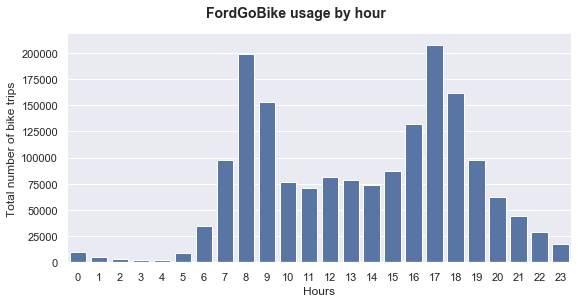

```python
g = sns.catplot(data=fordgobikes_master,x='start_time_hour',kind='count',color=base_color,height=4, aspect=8/4)
g.set_axis_labels('Hours','Total number of bike trips')
g.fig.suptitle('FordGoBike usage by hour',y=1.05,fontsize=14,fontweight='bold')
g.set_xticklabels(rotation=0);
```

**Observation: The above distribution is a bimodal distribution. The bikes saw the most usage during the morning hours of 8-9am, and in the evening hours of 5-6pm. This suggests that the bikes are being used primarily for work commutes.**

### 4. let's look at the FordGoBike system trip duration in seconds.

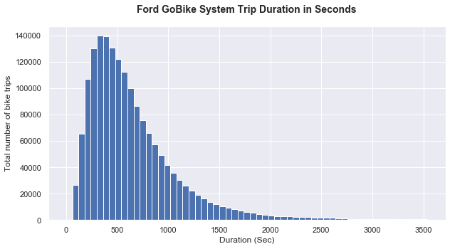

```python
bin_edges = np.arange(0,3600,60)
plt.figure(figsize=(10,5))
plt.hist(data=fordgobikes_master,x='duration_sec',bins=bin_edges)
plt.title("Ford GoBike System Trip Duration in Seconds", y=1.05, fontsize=14, fontweight='bold')
plt.xlabel('Duration (Sec)')
plt.ylabel('Total number of bike trips');
```

### 5. let's look at the FordGoBike system trip duration in minutes

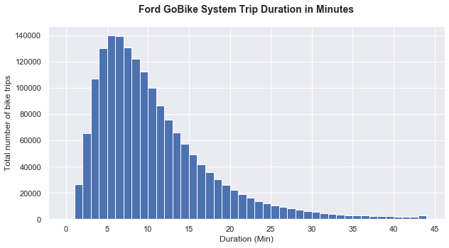

```python
bin_edges = np.arange(0, 45,1)
ticks = [0, 5, 10, 15, 20, 25, 30,  35, 40, 45]
labels = ['{}'.format(val) for val in ticks]
plt.figure(figsize=(10,5))
plt.hist(data = fordgobikes_master, x = 'duration_min', bins = bin_edges, rwidth = 1);
plt.title("Ford GoBike System Trip Duration in Minutes", y=1.05, fontsize=14, fontweight='bold')
plt.xlabel('Duration (Min)')
plt.xticks(ticks, labels)
plt.ylabel('Total number of bike trips');
```

### 6. let's look at the FordGoBike usage by age

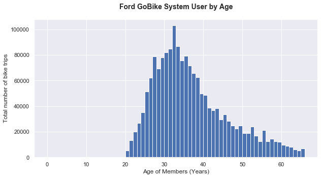

```python
bin_edges = np.arange(0, 67, 1)
plt.figure(figsize=(10,5))
plt.hist(data=fordgobikes_master,x='member_age',bins=bin_edges)
plt.title("Ford GoBike System User by Age", y=1.05, fontsize=14, fontweight='bold')
plt.xlabel('Age of Members (Years)')
plt.ylabel('Total number of bike trips');
```

```python
# Let's calculate average age of the user
fordgobikes_master.member_age.mean()
```

```
36.544169202313526
```

```python
#Let's take a look at the statistics of the member_age
fordgobikes_master.member_age.describe()
```

```
count    1.736572e+06
mean     3.654417e+01
std      9.700772e+00
min      2.000000e+01
25%      2.900000e+01
50%      3.400000e+01
75%      4.200000e+01
max      6.700000e+01
Name: member_age, dtype: float64
```

**Observation: The average age of a user is around 36 years old. Earlier, in the cleaning section of this data set all users over the age of 67 were removed as they were cited as outliers. The above histogram shows the most of the users fall between the ages of 29 - 42 years, which is also the same age range of working adults.**

### 7. let's look at the FordGoBike usage by Gender

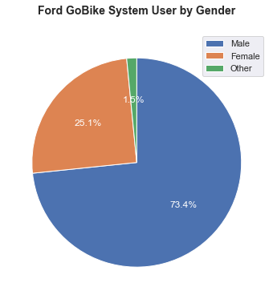

```python
gender = fordgobikes_master.member_gender.value_counts()
plt.figure(figsize=(10,6))
plt.pie(gender, labels = gender.index, startangle = 90, autopct= '%1.1f%%', counterclock = False, textprops={'color':'white'});
plt.title('Ford GoBike System User by Gender', y=1.05, fontsize=14, fontweight='bold');
plt.legend()
```

**Observation: As seen above, the pie chart tells majority of users of the bike share system are male, representing 73.4% of the total users. While, only 25.1% represent the female users.**

### 8. let's look at the user type split for FordGoBike sharing system

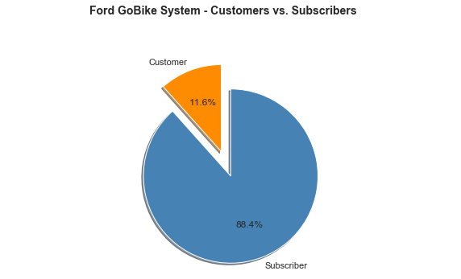

```python
# Let's calculate the customer and subscriber split
customer = fordgobikes_master.query('user_type == "Customer"')['bike_id'].count()
subscriber = fordgobikes_master.query('user_type == "Subscriber"')['bike_id'].count()
customer_prop = customer / fordgobikes_master['bike_id'].count()
subscriber_prop = subscriber / fordgobikes_master['bike_id'].count()

# Pie chart for user type
plt.figure(figsize=[10,5])

labels = ['Customer','Subscriber']
sizes = [customer_prop,subscriber_prop]
explode = (0,0.3)
colors = ['darkorange','steelblue']

plt.pie(sizes,explode=explode,labels=labels,colors=colors, autopct='%1.1f%%',shadow=True,startangle=90)
plt.axis('equal')
plt.suptitle('Ford GoBike System - Customers vs. Subscribers', y=1.05, fontsize=14, fontweight='bold');
```

**Observation: The bike sharing system is mainly used by subscribers (88%) than ocassional riders (12%).**

## Bivariate Exploration

> In this section, investigate relationships between pairs of variables in your data.

### 1. let's look at the monthly usage of FordGoBike bikes as per user type

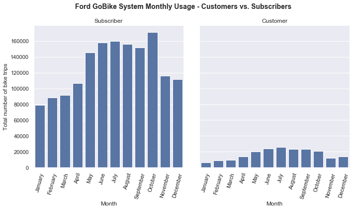

```python
g = sns.catplot(data=fordgobikes_master,x='start_time_month',col='user_type',color=base_color,sharey=True,kind='count',height=5, aspect=5/5)
g.set_axis_labels('Month','Total number of bike trips')
g.set_titles("{col_name}")
plt.suptitle('Ford GoBike System Monthly Usage - Customers vs. Subscribers', y=1.05, fontsize=14, fontweight='bold');
g.set_xticklabels(rotation=75);
```

**Customers,** the bike renting is high in demand around summertime, reaching its peak in July. Customers are most probably tourists, or the occasional riders who visit the Bay Area.

**Subscribers,** the highest demand is from May till October, reaching it's peak in October. I think the subscribers are most probably regular riders using bikes for their daily commute preferably for work due to the age range.

**It is evident that during winter months bike sharing is very less compared to other months.**

### 2. let's look at the weekly usage of FordGoBike bikes as per user type.

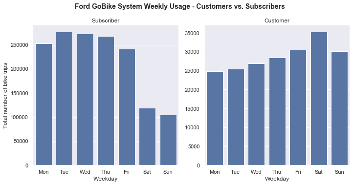

```python
weekday = ['Mon','Tue','Wed','Thu','Fri','Sat','Sun']
g = sns.catplot(data=fordgobikes_master,x='start_time_weekday',col='user_type',color=base_color,order=weekday,sharey=False,kind='count',height=5, aspect=5/5)
g.set_axis_labels('Weekday','Total number of bike trips')
g.set_titles("{col_name}")
plt.suptitle('Ford GoBike System Weekly Usage - Customers vs. Subscribers', y=1.05, fontsize=14, fontweight='bold');
```

**Observation:**There is a different trend for days on which customers and subscribers rent bikes.

**Customers,** Customers have a relatively low usage of the bike share system with a small increase on the weekends.Customers are most probably occasional riders and tourists who use the bike sharing system on holidays or weekend trips.

**Subscribers,** Subscribers have a steadily high usage on weekdays, with a sharp decline on the weekends. Subscribers are most probably daily work/school commuters who use the system throughout the week.

### 3. let's look at the hourly usage of FordGoBike bikes as per user type.

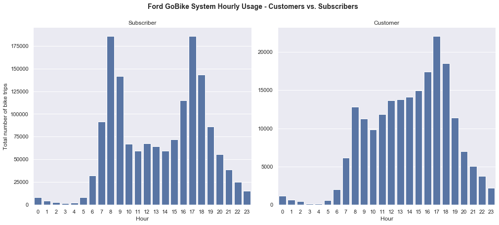

```python
g = sns.catplot(data=fordgobikes_master,x='start_time_hour',col='user_type',color=base_color,sharey=False,kind='count',height=6, aspect=7/6)
g.set_axis_labels('Hour','Total number of bike trips')
g.set_titles("{col_name}")
plt.suptitle('Ford GoBike System Hourly Usage - Customers vs. Subscribers', y=1.05, fontsize=14, fontweight='bold');
```

**Observation:**There is a different trend for what time of the day at which customers and subscribers rent bikes.

**Customers,** Customers use bikes mainly between 4 pm - 6 pm, reaching the renting peak around 5pm.

**Subscribers,** Subscribers use the bikes at around 8-9am and around 5-6pm presumably for their work commute.

### 4. let's look at the trip duration variation of FordGoBike bikes as per user type.

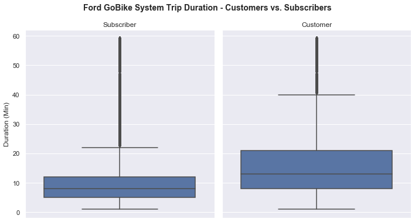

```python
# Let's plot a box plot to better understand the relationship
data = fordgobikes_master.query('duration_min < 60')
g = sns.catplot(data=data,y='duration_min',col='user_type',kind='box',color=base_color)
g.set_titles(col_template = '{col_name}')
g.set_axis_labels("", "Duration (Min)")
g.fig.suptitle('Ford GoBike System Trip Duration - Customers vs. Subscribers', y=1.05, fontsize=14, fontweight='bold');
```

### 5. let's look at the age distribution of users of FordGoBike bikes as per user type.

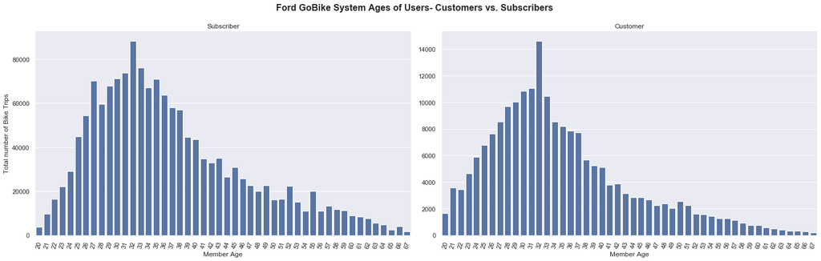

```python
graph = sns.catplot(data=fordgobikes_master, x = 'member_age', col='user_type', kind='count', sharey = False, color = base_color, height=6, aspect=10/6);

graph.set_axis_labels('Member Age', 'Total number of Bike Trips')
graph.set_titles('{col_name}')

graph.fig.suptitle('Ford GoBike System Ages of Users- Customers vs. Subscribers', y=1.05, fontsize=16, fontweight='bold');
graph.set_xticklabels(rotation=75);
```

### 6. Let's see the gender distribution for the user type of FordGoBike.

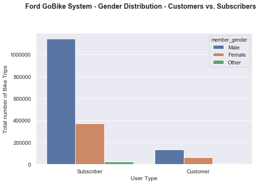

```python
plt.figure(figsize = [8, 5])
g = sns.countplot(data=fordgobikes_master,x='user_type',hue='member_gender',order=fordgobikes_master.user_type.value_counts().index)
g.set_xlabel('User Type')
g.set_ylabel('Total number of Bike Trips');
plt.suptitle('Ford GoBike System - Gender Distribution - Customers vs. Subscribers', y=1.05, fontsize=14, fontweight='bold');
```

**Observation:** In general, males are using the system more often than females and others (the registration system allows you to choose 'Other' as a gender). However, the ratio is much smaller between males and females for **Customers**(more ore less 2:1) than for **Subscribers**.

### Talk about some of the relationships you observed in this part of the investigation. How did the feature(s) of interest vary with other features in the dataset?

> Adding the user type to the analysis showed different usage behaviours between customers and subscribers. As mentioned above, customers are casual riders most probably tourists, or students on a vacation, who rent bikes mainly in summertime (the peak in July), more often during weekends than weekdays and they rent bikes more often in the evening hours. Subscribers are daily commuters or full time students who use the system during weekdays, and mostly for shorter distances. They mainly rent bikes before and after a typical work or school day (8-9am and 5-6pm).

### Did you observe any interesting relationships between the other features (not the main feature(s) of interest)?

> There is a difference in the trip duration between customers and subscribers. Customers trips are usually longer than for subscribers, most probably due to the fact they prefer bike rides around weekends in summertime, which may be for longer trips around the surrounding area. Subscribers on the other hand use the system mainly for short commute purposes so they rather prefer quick rides to and from work/school.

## Multivariate Exploration

> Create plots of three or more variables to investigate your data even further.

### 1. let's look at the monthly usage of FordGoBike bikes as per user type & gender

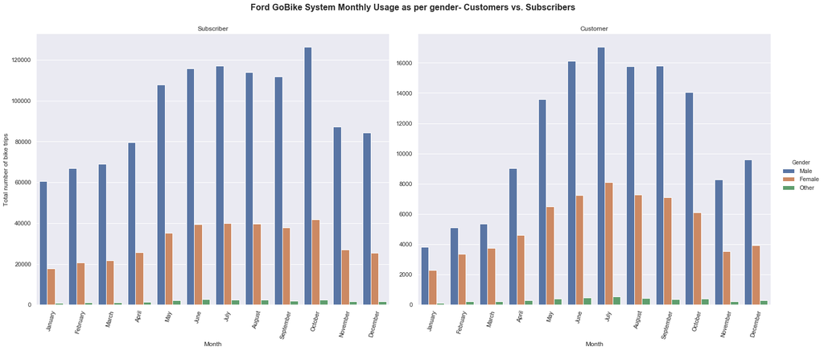

```python
g = sns.catplot(data=fordgobikes_master,x='start_time_month',col='user_type',hue='member_gender',sharey=False,kind='count', height=8, aspect=10/8)
g.set_axis_labels('Month','Total number of bike trips')
g.set_titles("{col_name}")
g._legend.set_title('Gender')
plt.suptitle('Ford GoBike System Monthly Usage as per gender- Customers vs. Subscribers', y=1.05, fontsize=16, fontweight='bold');
g.set_xticklabels(rotation=75);
```

**Observation:** The trend is kinda similar for both males and females.  
For **Customers,** the highest demand is around summertime, reaching its peak in July; For **Subscribers,** the highest demand is from May till October, reaching it's peak in October.  
Suprisingly, for **Customers** there are quite a lot of females using the system between January and March in comparison to males - the ratio is much smaller than for the rest of the year.

### 2. let's look at the weekly usage of FordGoBike bikes as per user type & gender

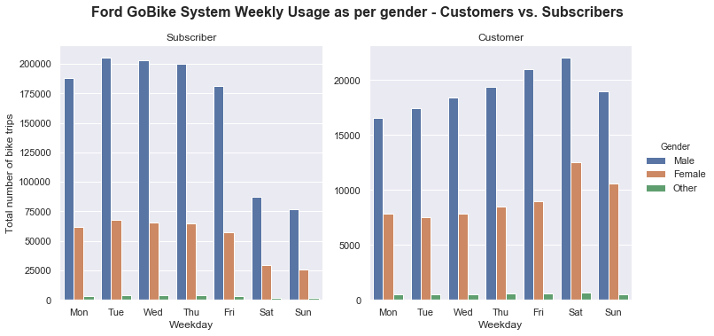

```python
weekday = ['Mon','Tue','Wed','Thu','Fri','Sat','Sun']
g = sns.catplot(data=fordgobikes_master,x='start_time_weekday',col='user_type',hue='member_gender',order=weekday,sharey=False,kind='count')
g.set_axis_labels('Weekday','Total number of bike trips')
g.set_titles("{col_name}")
g._legend.set_title('Gender')
plt.suptitle('Ford GoBike System Weekly Usage as per gender - Customers vs. Subscribers', y=1.05, fontsize=16, fontweight='bold');
```

**Observation:** As in the previous section, the trend is very similar for males and females:  
For **Customers,** the highest demand is often during weekends than weekdays (although the jump in bike used on weekends is much higher for females than for males).  
For **Subscribers** the demand is mainly within the week.

### 3. let's look at the hourly usage of FordGoBike bikes as per user type & gender

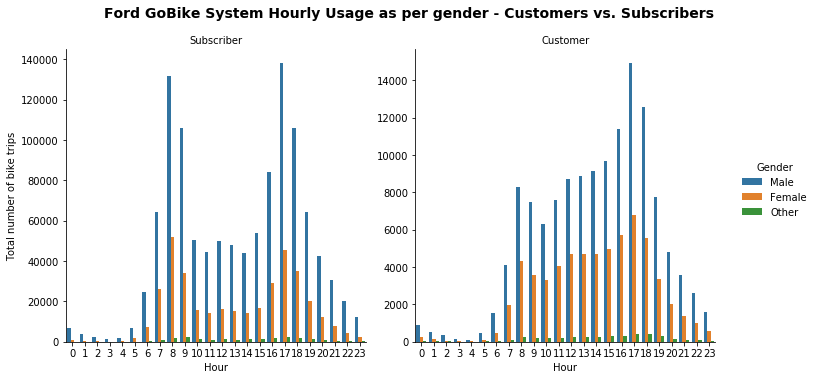

```python
g = sns.catplot(data=fordgobikes_master,x='start_time_hour',col='user_type',hue='member_gender',sharey=False,kind='count')
g.set_axis_labels('Hour','Total number of bike trips')
g.set_titles("{col_name}")
g._legend.set_title('Gender')
plt.suptitle('Ford GoBike System Hourly Usage as per gender - Customers vs. Subscribers', y=1.05, fontsize=14, fontweight='bold');
```

**Observation:** During the day, both males and females use the system the same way.  
For **Customers,** they use bikes mainly between 8 am - 7 pm.  
For **Subscribers,** they use the system at around 8-9am and 5-6pm when they go and come back from work. One thing to notice here is that, there's a major downfall of female users especially during the morning hours.

### 4. let's look at the Trip duration of FordGoBike bikes as per user type & gender¶

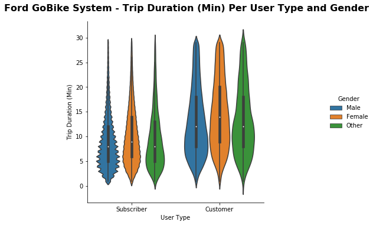

```python
data=fordgobikes_master.query('duration_min<30')
g = sns.catplot(data=data, x='user_type', y="duration_min", hue="member_gender", kind="violin");

g.set_axis_labels("User Type", "Trip Duration (Min)")
g._legend.set_title('Gender')
g.fig.suptitle('Ford GoBike System - Trip Duration (Min) Per User Type and Gender', y=1.05, fontsize=16, fontweight='bold');
```

**Observation:** In both cases, females take longer trips (measured in mins) than males and other genders. The difference is more visible for customers (~13 min for males and other vs ~15 for females) than for subscribers (the difference is quite small).

### let's look at the hourly usage throughout the week of FordGoBike bikes as per user type

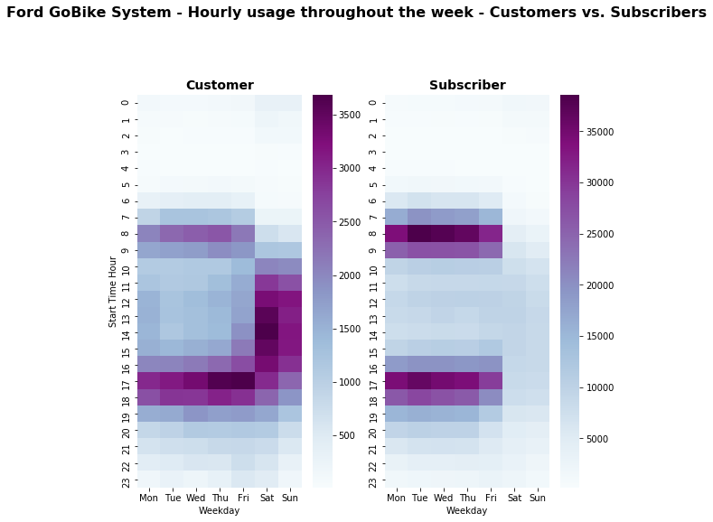

```python
# Let's set the weekday order
fordgobikes_master['start_time_weekday'] =  pd.Categorical(fordgobikes_master['start_time_weekday'],
                                                categories=['Mon','Tue','Wed','Thu','Fri','Sat', 'Sun'],
                                                ordered=True)
plt.figure(figsize=(9,8))
plt.suptitle('Ford GoBike System - Hourly usage throughout the week - Customers vs. Subscribers', y=1.05, fontsize=16, fontweight='bold');


#Plotting a heatmap for Customers
plt.subplot(1,2,1)
df_customer = fordgobikes_master.query('user_type == "Customer"').groupby(["start_time_hour", "start_time_weekday"])["bike_id"].size().reset_index()
df_customer = df_customer.pivot('start_time_hour','start_time_weekday','bike_id')
sns.heatmap(df_customer,cmap='BuPu')
plt.title("Customer", y=1.015, fontsize=14, fontweight='bold')
plt.xlabel('Weekday')
plt.ylabel('Start Time Hour');


#Plotting a heatmap for Subscribers
plt.subplot(1,2,2)
df_subscriber = fordgobikes_master.query('user_type == "Subscriber"').groupby(["start_time_hour", "start_time_weekday"])["bike_id"].size().reset_index()
df_subscriber = df_subscriber.pivot('start_time_hour','start_time_weekday','bike_id')
sns.heatmap(df_subscriber,cmap='BuPu')
plt.title("Subscriber", y=1.015, fontsize=14, fontweight='bold')
plt.xlabel('Weekday')
plt.ylabel('');
```

**Observation:** The plot perfectly summarizes the different trends altogether for customers and subscribers I was visualizing in the above plots.

**Customers ride the FordGoBikes more often on weekends:**

- Weekdays(Mon-Fri): Most rides happen around 8-9am and 5-6pm with the peak on Fridays around 5pm.
- Weekends(Sat-Sun): Most rides happen between 11am - 6pm with the peak on Saturdays around 1pm - 2pm.

**Subscribers use the bike sharing system mostly on weekdays:**

- Weekdays(Mon-Fri): Most rides happen around 8-9am and 5-6pm with the peak on Tuesdays around 8am.
- Weekends(Sat-Sun): The bikes are hardly rented during the weekends as most of them use the bikes for daily work commute.

### Talk about some of the relationships you observed in this part of the investigation. Were there features that strengthened each other in terms of looking at your feature(s) of interest?

> This section enhanced the previous topics of data exploration through different visuals and adding in more variables to compare to other variables. Plotting a heatmap of demand of the bikes throughout the day on a weekly basis shed a new light on the time based discussion on when and what time each user group uses the bike sharing system. Plotting the bike trips throughout the day and bike trips within the weekdays separately gave the impression that the demand for bikes is quite high throughout the day with a peak around 5pm which is not entirely true. The trend within weekdays for customers follows the one for subscribers who rent bikes mainly around commute hours (8-9am and 5-6pm). For customers, as depicted in bivariate explorations, most of the trips happen on weekends but mainly between 11am - 6pm with the peak on Saturdays around 2pm, what was previously not visible only possible through the multivariate exploration. By adding gender as the hue for each plot, we got a better understanding of the gender distribution for the usage of the FordGoBikes.

### Were there any interesting or surprising interactions between features?

> Nothing out of the blue here. It was interesting to note the sharp monthly difference for Males vs. Females vs. Other, and how close the Female count got to the Male Customer count in January through March. This may be a potential loss of possible Customers converting to Subscribers.Moreover Females take longer trips than Males and others.